# 2: Assigning farm locations

FAO Climate Change Risks to Fed Mariculture

Author

Tormey Reimer

Published

9 October 2026

← Previous: Choosing Species

Next: Parameterise species: `atlantic_salmon` →

# Overview

This document imports data from Clawson et al. (2022) on known and modelled mariculture locations and assigns farms to the species being modelled here. However, there are some challenges to overcome in this process:

- The data from Clawson et al. (2022) is from 2017 and was based on contemporary aquaculture production data, which has increased significantly since then (and possibly changed in relative species production). New aquaculture locations will not be estimated to accomodate for this - instead, each location will likely produce more than is intended. This is because the aim of this study is to examine change in production/feed demand with climate change, not accurately predict current production.
- There are some gaps acknowledged by Clawson et al. (2022), particularly surrounding China’s production locations.
- There is a possibility that any particular country/FAO fishing region will not have enough farms or farms of a specified type to accomodate all of that country’s production. In this case, we will use habitat suitability (temperature range) to place additional farms within that country’s EEZ.

This is the overall process followed when assigning farms:

```
%%{init: {'theme': 'base', 'themeVariables': {
  'primaryColor': '#ffffff',
  'primaryBorderColor': '#2c5f8a',
  'lineColor': '#e74c3c',
  'lineWidth': '3px',
  'edgeLabelBackground': '#ffffff'
}}}%%
flowchart TD
  Start[For each region: country x FAO fishing area]

  Start --> Farms(Are there any farms mapped to this region?)
  Farms -->|Yes| F(Calculate number of farms needed for reasonable production of all models. Are there enough farms to cover that?)
  Farms -->|No| NoFarms[Extract meanyear temperatures for all coastal gridcells, calculate suitability overlap with all models]

  F -->|Yes| A(How many different models need to be assigned?)

  A -->|Just one| D[Assign required number of farms to that model]
  D --> Done1

  A -->|Multiple| YesFarms[Extract meanyear temperatures for all farms, calculate suitability overlap with all models]
  YesFarms --> TempSuitCalc2[Assign required number of farms to maximise overall suitability]
  TempSuitCalc2 --> Done1

  F -->|No| Z[Assign as many farms as possible, adjust required number of farms to reflect]
  Z --> NoFarms

  NoFarms --> J[Place required number of farms >= 0.25 deg apart, to maximise suitability]
  J --> Done1

  Done1[Collate all assignments together] --> Done[Done! fa:fa-trophy]
```

# Get data

**Get mariculture locations data**

```r
aqua_locs <- file.path(prepdata_path, "mariculture_locations_FAO_codes.qs") %>%
    qd_read() %>%
    rename(ISO3_Code = iso3c) %>%
    mutate(across(where(is.character), str_trim))
```

**Make sure the mariculture locations data looks right**

```
ℹ Adding new coordinate system, which will replace the existing one.
```

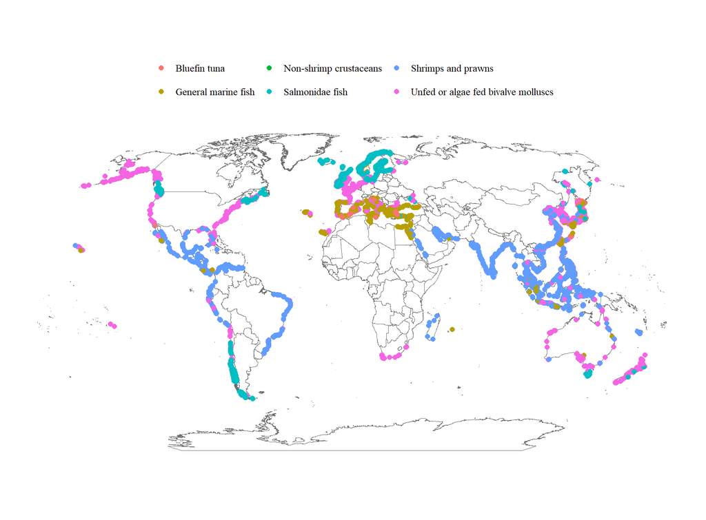

Figure 1: Map of mariculture locations as mapped in 2017, coloured by species group.

```r
p_bigmap_robinson +
  geom_sf(
    data = aqua_locs %>% st_transform(crs = crs_robin),
    aes(color = species_group, geometry = geometry),
    size = 2
  ) +
  coord_sf() +
  prettyplot() +
  theme(legend.position = "top") +
  rm_x_axis() + rm_y_axis()
```

**Get prepared production data - already filtered by assigned model names**

```r
FAO_aqua <- file.path(prepdata_path, "FAO_with_models_final_production.csv") %>%
    read.csv() %>%
    mutate(across(where(is.character), str_trim))

# Get FAO fishing region code keys and add to production data
FAO_code_key <- file.path(prepdata_path, "FAO_code_key.csv") %>%
    read.csv() %>% select(-X)
FAO_aqua <- FAO_aqua %>%
    left_join(FAO_code_key, by = c("fao_fishing_area" = "NAME_EN"))

# Check that none were left blank
# FAO_aqua %>%
#     filter(is.na(F_CODE)) %>%
#     pull(fao_fishing_area) %>%
#     unique()

# Add groups based on the location data groups
FAO_aqua <- FAO_aqua %>%
    mutate(
        location_group = case_when(
            model_name %in% c("tuna") ~ "Bluefin tuna",
            model_name %in% c("rainbow_trout", "atlantic_salmon") ~ "Salmonidae fish",
            model_name %in% c("whiteleg_shrimp", "tiger_prawn") ~ "Shrimps and prawns",
            model_name %in% c("mud_crab") ~ "Non-shrimp crustaceans",
            model_name %in% c("japanese_sea_cucumber", "abalone") ~ "Unfed or algae fed bivalve molluscs",
            TRUE ~ "General marine fish",
        )
    ) %>%
    select(-c(fao_fishing_area, species_name, environment)) %>%
    filter(location_group != "Unfed or algae fed bivalve molluscs")

# Somehow some 99% landlocked countries made it in here
FAO_aqua <- FAO_aqua %>%
  filter(!country %in% c("Bosnia and Herzegovina", "Slovenia"))

head(FAO_aqua)
```

```
  period value country ISO3_Code       model_name F_CODE      location_group
1   2012   400 Albania       ALB european_seabass     37 General marine fish
2   2014   700 Albania       ALB european_seabass     37 General marine fish
3   2016   800 Albania       ALB european_seabass     37 General marine fish
4   2018  1000 Albania       ALB european_seabass     37 General marine fish
5   2020  2875 Albania       ALB european_seabass     37 General marine fish
6   2022  2622 Albania       ALB european_seabass     37 General marine fish
```

Production has increased since 2017 (see Figure 2). Since the aquaculture mapping data was based on production data, there will be some additional uncertanties based on this change - however the only real implications will be changes in the ratios of species produced. However, from Figure 2, it looks like the changes aren’t all that drastic. Still, production per farm will be increased from 2017 to 2025 and we will need to check that per-farm production isn’t unreasonably high.

**Show how production of each mapped group has changed in the last 5 years**

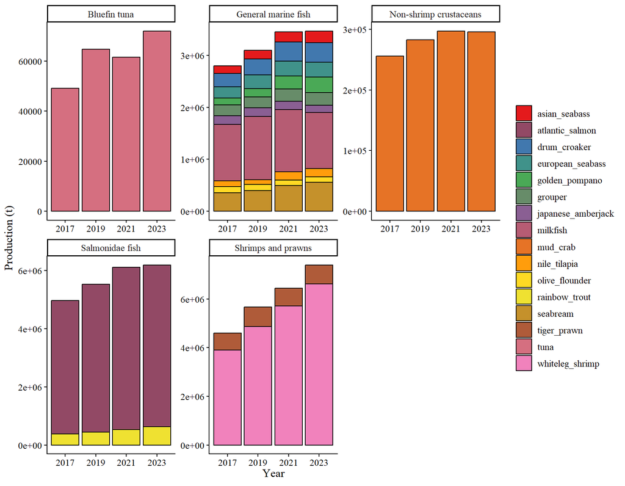

Figure 2: Comparing global production of each `model_name` from 2017 – 2023, split by the groupings present in the aquaculture mapping data.

```r
FAO_aqua %>%
    # I don't know why the years are paired like this in the data but they are - even-numbered years have ~3x the production of odd numbered years
    mutate(period = case_when(
        period %in% 2022:2023 ~ 2023,
        period %in% 2020:2021 ~ 2021,
        period %in% 2018:2019 ~ 2019,
        period %in% 2016:2017 ~ 2017
    )) %>%
    group_by(period, model_name, location_group) %>%
    reframe(total_value = sum(value, na.rm = T)) %>%
    filter(period %in% c(2017:max(FAO_aqua$period))) %>%
    ggplot(aes(
        x = as.factor(period),
        y = total_value,
        fill = model_name
    )) +
    geom_col(colour = "black") +
    facet_wrap(~location_group, scales = "free") +
    scale_fill_manual(
        name = "Model name",
        values = colorRampPalette(brewer.pal(9, "Set1"))(18)
    ) +
    prettyplot() +
    theme(legend.position = "right") +
    labs(
        x = "Year", y = "Production (t)"
    )
```

```r
FAO_aqua_means <- FAO_aqua %>%
    filter(period >= 2017) %>%
    group_by(ISO3_Code, country, F_CODE, location_group, model_name) %>%
    reframe(value = mean(value, na.rm = TRUE)) %>%
    filter(value != 0)

FAO_aqua_means <- FAO_aqua_means %>%
  mutate(location_group = case_when(
    model_name == "tuna" ~ "Bluefin tuna",
    model_name == "mud_crab" ~ "Non-shrimp crustaceans",
    model_name %in% c("whiteleg_shrimp", "tiger_prawn") ~ "Shrimps and prawns",
    model_name %in% c("atlantic_salmon", "rainbow_trout") ~ "Salmonidae fish",
    model_name %in% c("abalone", "japanese_sea_cucumber") ~ "Unfed or algae fed bivalve molluscs",
    T ~ "General marine fish"
  ))

head(FAO_aqua_means)
```

```
# A tibble: 6 × 6
  ISO3_Code country              F_CODE location_group      model_name     value
  <chr>     <chr>                 <int> <chr>               <chr>          <dbl>
1 ALB       Albania                  37 Bluefin tuna        tuna             96
2 ALB       Albania                  37 General marine fish european_seab… 2166.
3 ALB       Albania                  37 General marine fish seabream       3521.
4 ARE       United Arab Emirates     51 General marine fish european_seab…  523
5 ARE       United Arab Emirates     51 General marine fish grouper         215
6 ARE       United Arab Emirates     51 General marine fish japanese_ambe…  100
```

# Prep for assignment

**Fix inconsistencies in the ways countries are named in the two datasets**

```r
countries_fix <- left_join(
    FAO_aqua_means %>% distinct(ISO3_Code, country),
    aqua_locs %>% st_drop_geometry() %>% distinct(ISO3_Code, country),
    by = "ISO3_Code"
) %>%
    mutate(country = case_when(
        is.na(country.x) ~ country.y,
        is.na(country.y) ~ country.x,
        T ~ country.y
    )) %>%
    select(ISO3_Code, country)

# Fix country names!
FAO_aqua_means <- FAO_aqua_means %>%
    rows_update(countries_fix, by = c("ISO3_Code"))
locs_crs <- st_crs(aqua_locs)
aqua_locs <- aqua_locs %>%
    mutate(lon = st_coordinates(aqua_locs)[, 1], lat = st_coordinates(aqua_locs)[, 2]) %>%
    st_drop_geometry() %>%
    rows_update(
        filter(countries_fix, ISO3_Code %in% aqua_locs$ISO3_Code),
        by = "ISO3_Code"
    ) %>%
    st_as_sf(coords = c("lon", "lat"), crs = locs_crs)
```

The number of farms mapped to a specific location group may not match the number of farms required to acheive reasonable per-farm production based on tonnage from the FAO. We need to calculate the number of farms required to get reasonable tonnage in each country, region and location group.

```r
# Honduras' only production is of whiteleg shrimp in FAO region 77, but the area is too small to extract temperatures. Instead, we'll be moving their production to region 31. This already has shrimp/prawn farms mapped, so the error won't be too egregious.
FAO_aqua_means$F_CODE[FAO_aqua_means$ISO3_Code == "HND"] <- 31
```

- If assigning all available farms results in current per-farm production between $0.95 \times$ and $2.5 \times$ 2017 production, then the number of farms required = number of farms available. In this scenario, per-farm production is allowed to change slightly but the number of farms is assumed to be the same. Note that the actual ratio per species may vary, as some location groups cover more than one species.
- If assigning all available farms results in current per-farm production $\geq 2.5 \times$ 2017 production, then the number of farms needs to be expanded. In this case, production has increased so much that new farms must have been added (or the farms mapped are an incomplete subset). The number of required farms is set based on keeping current per-farm production $= 2.5 \times$ 2017 production.
- If assigning all available farms results in current per-farm production $< 0.95 \times$ 2017 production, then the number of farms needs to be reduced. In this scenario, the location category likely includes many other species/groups that we have excluded from the analysis. The number of required farms is set based on keeping current per-farm production $=$ 2017 production.

**Calculate the number of farms required for each country/region/location group**

```r
mapped_farms <- aqua_locs %>%
  st_drop_geometry() %>%
  group_by(country, F_CODE, species_group) %>%
  reframe(
    n_farms = n(),
    per_farm_prod_2017 = mean(tonnes_per_farm, na.rm = T)
  )

# Calculate required farms where there are already farms mapped
farms_required <- FAO_aqua_means %>%
  group_by(country, F_CODE, location_group) %>%
  reframe(
    model_names = n_distinct(model_name),
    total_production = sum(value)
  ) %>%
  ungroup() %>%
  left_join(mapped_farms, by = c("country", "F_CODE", "location_group" = "species_group")) %>%
  mutate(
    per_farm_prod_now = total_production/n_farms,
    prod_ratio = per_farm_prod_now/per_farm_prod_2017,
    total_farms_required = case_when(
      # special case for FI because their per-farm production is extremely high
      country == "Faroe Islands" & location_group == "Salmonidae fish" & prod_ratio > 1 ~ total_production/(1*per_farm_prod_2017),
      prod_ratio <= 2.5 & prod_ratio >= 0.95 ~ n_farms,
      prod_ratio > 2.5 ~ total_production/(2.5*per_farm_prod_2017),
      prod_ratio < 0.95 ~ total_production/(1*per_farm_prod_2017)
    ),
    total_farms_required = pmax(ceiling(total_farms_required), model_names),
    per_farm_prod_fixed = total_production/total_farms_required
  )

# Estimate required farms where there are no farms mapped
farms_required <- farms_required %>%
  mutate(per_farm_prod_now = total_production/total_farms_required) %>%
  select(-per_farm_prod_2017) %>%
  group_by(location_group) %>%
  mutate(typical_per_farm_prod = mean(per_farm_prod_now, na.rm = T)) %>%
  ungroup() %>%
  mutate(
    total_farms_required = case_when(
      !is.na(total_farms_required) ~ total_farms_required,
      T ~ ceiling(total_production/typical_per_farm_prod)
    ) %>% as.integer(),
    per_farm_prod_fixed = total_production/total_farms_required
  )

# Distill into a reference table for lookup later
farms_required <- farms_required %>%
  mutate(
    # Farm temperatures are needed if:
    #   - There are more farms mapped than required (not all farms will be assigned)
    #   - There are fewer farms mapped than required (some will be assigned)
    #   - There is more than one model name to assign
    farm_temps_needed = !is.na(n_farms) & (total_farms_required != n_farms | model_names > 1),
    # Grid cell temperatures are needed if:
    #   - There are no farms mapped, or there are more farms required than mapped (new farms need to be created)
    cell_temps_needed = is.na(n_farms) | (total_farms_required > n_farms)
  ) %>%
  select(country, F_CODE, location_group, n_farms, model_names, total_farms_required, farm_temps_needed, cell_temps_needed) %>%
  mutate(ISO3_Code = countrycode(country, origin = "country.name", destination = "iso3c"))

cat("\nTotal regions: ", nrow(farms_required))
```

```
Total regions:  210
```

**Calculate the number of farms required for each country/region/location group**

```r
cat("\nRegions where mapped farms cover required farms for simple assignment: ", farms_required %>% filter(!farm_temps_needed & !cell_temps_needed) %>% nrow())
```

```
Regions where mapped farms cover required farms for simple assignment:  30
```

**Calculate the number of farms required for each country/region/location group**

```r
cat("\nRegions where only farm temperatures are required for assignment: ", farms_required %>% filter(farm_temps_needed & !cell_temps_needed) %>% nrow())
```

```
Regions where only farm temperatures are required for assignment:  61
```

**Calculate the number of farms required for each country/region/location group**

```r
cat("\nRegions where only cell temperatures are required for assignment: ", farms_required %>% filter(!farm_temps_needed & cell_temps_needed) %>% nrow())
```

```
Regions where only cell temperatures are required for assignment:  101
```

**Calculate the number of farms required for each country/region/location group**

```r
cat("\nRegions where both farm and cell temperatures are required for assignment: ", farms_required %>% filter(farm_temps_needed & cell_temps_needed) %>% nrow())
```

```
Regions where both farm and cell temperatures are required for assignment:  18
```

**Remove blank norway farms**

```r
to_exclude_norway <- c("87416","87479","87520","87521","87525", "88018")

aqua_locs <- aqua_locs %>%
  filter(!farm_ID %in% to_exclude_norway)

norway_blanks <- farms_required %>%
  filter(ISO3_Code == "NOR") %>%
  mutate(
    n_farms = n_farms - length(to_exclude_norway),
    total_farms_required = total_farms_required - length(to_exclude_norway)
  ) %>%
  select(ISO3_Code, n_farms, total_farms_required)

farms_required <- rows_update(
  farms_required,
  norway_blanks,
  by = c("ISO3_Code")
)
```

The `farms_required` dataframe is split into four groups up front so that the assignment method for every region is clear before any assignment begins. A single `assigned_farms` dataframe accumulates results across all four groups; each group checks this dataframe first and excludes any already-assigned mapped farms from its working copy of `aqua_locs`.

**Split farms_required into the four assignment groups**

```r
farms_required_1 <- farms_required %>% filter(!farm_temps_needed & !cell_temps_needed)
farms_required_2 <- farms_required %>% filter( farm_temps_needed & !cell_temps_needed)
farms_required_3 <- farms_required %>% filter(!farm_temps_needed &  cell_temps_needed)
farms_required_4 <- farms_required %>% filter( farm_temps_needed &  cell_temps_needed)

cat("Group 1 (simple assignment):          ", nrow(farms_required_1), "regions\n")
```

```
Group 1 (simple assignment):           30 regions
```

**Split farms_required into the four assignment groups**

```r
cat("Group 2 (mapped, temperature-based):  ", nrow(farms_required_2), "regions\n")
```

```
Group 2 (mapped, temperature-based):   61 regions
```

**Split farms_required into the four assignment groups**

```r
cat("Group 3 (habitat extraction only):    ", nrow(farms_required_3), "regions\n")
```

```
Group 3 (habitat extraction only):     101 regions
```

**Split farms_required into the four assignment groups**

```r
cat("Group 4 (mixed mapped + extraction):  ", nrow(farms_required_4), "regions\n")
```

```
Group 4 (mixed mapped + extraction):   18 regions
```

**Split farms_required into the four assignment groups**

```r
# Single collector for all assigned farms - starts empty
assigned_farms <- NULL
```

# Assign locations

## Group 1: Simple assignments

In some regions, the number of mapped farms is appropriate for the single `model_name` that needs to be assigned. These are the easiest to assign and it is done without looking at any temperatures.

**Assign farms to groups where simple one-to-one assignment is sufficient**

```r
for (i in 1:nrow(farms_required_1)) {
  # Exclude any farms already assigned in a previous iteration
  aqua_locs_1 <- aqua_locs %>%
    filter(!farm_ID %in% assigned_farms$farm_ID) %>%
    filter(country == farms_required_1$country[i] & F_CODE == farms_required_1$F_CODE[i] & species_group == farms_required_1$location_group[i])
  FAO_aqua_means_1 <- FAO_aqua_means %>%
    filter(country == farms_required_1$country[i] & F_CODE == farms_required_1$F_CODE[i] & location_group == farms_required_1$location_group[i])

  result_1 <- aqua_locs_1 %>%
    mutate(
      source     = "mapped",
      model_name = FAO_aqua_means_1$model_name,
      prod_perfarm = FAO_aqua_means_1$value / nrow(aqua_locs_1)
    ) %>%
    select(-c(tonnes_per_farm, NAME_EN))

  assigned_farms <- rbind(assigned_farms, result_1)
}
```

## Group 2: Mapped assignments

In some regions, there are more than enough farms to assign to all the `model_names` required but some additional decisions need to be made based on farm temperatures. Farm temperatures are extracted from a “mean year” created by `data-prep-scripts\historical-sst.R`.

**Define a function that will extract a meanyear of temperatures from any location**

```r
farm_temp_path <- file.path(prepdata_path, "mapped_farms_meanyear")
dir.create(farm_temp_path, recursive = T, showWarnings = F)

global_raster_files <- file.path(prepdata_path, "analysed-SST-MUR25-v4.2_meanyear") %>%
  list.files(full.names = T) %>%
  sort()

global_raster_stack <- terra::rast(global_raster_files)
names(global_raster_stack) <- paste0("DOY_", 1:length(global_raster_files))

# The actual temperature extraction function extract_point_location_temperature() has been moved to other_functions.R
```

This next chunk gets the typical mean year of temperatures for each farm location from a “typical year” constructed from the years 2017 - 2023 (see historical-sst.R for details). The process for each farm is as follows:

1. Try to extract a temperature vector from the exact farm location point. This was usually successful, however sometimes the temperature vector would come back as all-`NA` (the data has no temporal gaps but there are some spatial gaps).
2. In this case, temperature vectors are extracted from the 8 surrounding cells (up to 0.25 degrees away in all directions) and a mean is taken.
3. If this still returns an all-`NA` vector, the search is extended to one more cell in the east and west directions only (6 more cells in total, up to 0.5 degrees away). During the extraction process these cells returned a warning, enabling us to see that < 0.5% of cells made it to this step.
4. If this STILL returns an all-`NA` vector, the search is extended for a final time to to two more cells in the east and west directions only (12 more cells, up to 1 degree away). Approximately 0.16% of cells made it to this step.
5. If this STILL returns an all-`NA` vector, the extraction process finally gives up.

**Extract and save the mean daily temperatures at all the farms that might be assigned to Group 2 (or Group 4).**

```r
combined <- rbind(farms_required_2, farms_required_4)

for (i in 1:nrow(combined)) {
  cat(sprintf("Starting region %d of %d, extracting %d farms...\n", i, nrow(combined), combined$n_farms[i]))

  this_country <- combined$country[i]
  this_F_CODE <- combined$F_CODE[i]
  this_species_group <- combined$location_group[i]

  aqua_locs_2 <- aqua_locs %>%
    filter(!farm_ID %in% assigned_farms$farm_ID) %>%
    filter(country == this_country & F_CODE == this_F_CODE & species_group == this_species_group) %>%
    group_by(farm_ID) %>%
    group_split()

  this_path <- file.path(farm_temp_path, paste(this_country, this_F_CODE, this_species_group, sep = "_"))
  dir.create(this_path, showWarnings = F)

  walk(
    aqua_locs_2,
    extract_point_location_temperature,
    global_raster_stack = global_raster_stack,
    out_path = this_path,
    overwrite = F,
    .progress = T
  )
}
```

After the extraction process, some farms failed to get any temperature data from the rasters (they were probably too far up rivers so were considered “inland”). However, there are only a few of them and they’re in countries where there are already plenty of farms (2 in Chile, 1 in Croatia, 1 in Ireland), so these problem farms are simply excluded.

**Find blank farms and deal with them**

```r
# # Check for blank farms
# temp_check <- farm_temp_path %>%
#   list.files(full.names = T, recursive = T) %>%
#   map_dfr(function(fnm) {
#     data.frame(
#       farm_ID = fnm %>% basename() %>% str_split_i(pattern = "_", 3) %>% str_remove(".qs") %>% as.integer(),
#       blank = qd_read(fnm) %>% pull(sst) %>% is.na() %>% any()
#     )
#   },
#   .progress = T
# ) %>%
#   filter(blank)

# # Limit to mapped locations
# blank_farms <- temp_check %>% pull(farm_ID)

blank_farms <- c(85774, 85775, 84446, 87250) # shortcut

# Show where the farms are
bf_region <- aqua_locs %>%
  st_drop_geometry() %>%
  filter(farm_ID %in% blank_farms) %>%
  distinct(country, F_CODE, species_group, farm_ID)

farms_required_blank <- farms_required %>%
  inner_join(bf_region, by = c("country", "F_CODE", "location_group" = "species_group")) %>%
  select(-c(model_names, farm_temps_needed, cell_temps_needed, farm_ID)) %>%
  group_by(country, F_CODE, location_group, total_farms_required, n_farms) %>%
  reframe(farms_removed = n()) %>%
  mutate(
    original_farms_required = total_farms_required,
    total_farms_required = total_farms_required - farms_removed
  )

farms_required_blank

# There are two different situations here. One is Chile/Croatia: all farms need to be used, but there are blank farms. We simply remove them - per-farm production will increase slightly, but that's ok. In the other two cases, the farms can safely be removed without adjusting the number of farms required.

# Remove the blank farms from the possible pool
aqua_locs <- aqua_locs %>%
  filter(!farm_ID %in% blank_farms)

# Also adjust the farms required (all these blank farms are in places included in farms_required_2)
farms_required_2 <- rows_update(
  farms_required_2,
  farms_required_blank %>% select(-c(farms_removed, original_farms_required)),
  by = c("country", "F_CODE", "location_group")
)
```

**Function to optimise location assignment based on the number of days spent within each model’s ideal ranges**

```r
assign_models <- function(ideal_days_df, n_required) {
  model_cols   <- names(n_required)
  loc_ids      <- ideal_days_df$farm_ID
  n_loc        <- nrow(ideal_days_df)
  n_models     <- length(model_cols)
  n_vars       <- n_loc * n_models

  # Extract values matrix internally for indexing convenience
  val_mat <- ideal_days_df %>% select(all_of(model_cols)) %>% as.matrix()
  rownames(val_mat) <- as.character(loc_ids)

  obj           <- as.vector(val_mat)
  obj[obj < 30] <- 0

  # Constraint 1: each location assigned to at most one model_name
  loc_constraints <- matrix(0, nrow = n_loc, ncol = n_vars)
  for (i in seq_len(n_loc)) {
    idx <- i + (seq_len(n_models) - 1) * n_loc
    loc_constraints[i, idx] <- 1
  }

  # Constraint 2: each model_name assigned to exactly n_required locations
  mod_constraints <- matrix(0, nrow = n_models, ncol = n_vars)
  for (j in seq_len(n_models)) {
    idx <- ((j - 1) * n_loc + 1):(j * n_loc)
    mod_constraints[j, idx] <- 1
  }

  # Constraint 3: ineligible cells (< 30 days) fixed to 0
  ineligible         <- which(val_mat < 30)
  n_inelig           <- length(ineligible)
  inelig_constraints <- matrix(0, nrow = n_inelig, ncol = n_vars)
  for (k in seq_len(n_inelig)) {
    inelig_constraints[k, ineligible[k]] <- 1
  }

  all_constraints <- rbind(loc_constraints, mod_constraints, inelig_constraints)
  all_dirs        <- c(rep("<=", n_loc), rep("=", n_models), rep("=", n_inelig))
  all_rhs         <- c(rep(1, n_loc), n_required[model_cols], rep(0, n_inelig))

  result <- lp(
    direction    = "max",
    objective.in = obj,
    const.mat    = all_constraints,
    const.dir    = all_dirs,
    const.rhs    = all_rhs,
    all.bin      = TRUE
  )

  if (result$status != 0) stop("No feasible solution found (status ", result$status, ")")

  x_mat    <- matrix(result$solution, nrow = n_loc, ncol = n_models, dimnames = list(loc_ids, model_cols))
  assigned <- which(x_mat == 1, arr.ind = TRUE)

  data.frame(
    farm_ID    = loc_ids[assigned[, 1]],
    model_name = model_cols[assigned[, 2]],
    row.names = NULL
  )
}
```

“Temperature suitability” here refers only to a species’ feeding response. If a species’ relative feeding response is >0.5 then a temperature is considered suitable for that species. It’s a pretty broad definition of suitability.

**Get the ideal temperature ranges for each model**

```r
# Default feeding temperature function
feeding_rate <- function(
  temperature,   # current temperature
  Toa,           # optimum feeding temperature
  Tma,           # maximum feeding temperature
  betac = 0.3234 # defualt shape coefficient uses the seabream value from Baldan et al. (2018)
) {
  exp(betac * (temperature - Toa)) * ((Tma - temperature) / (Tma - Toa))^(betac * (Tma - Toa))
}

ideal_temperatures <- unique(FAO_aqua_means$model_name) %>%
  sort() %>%
  map_dfr(function(mn) {
    xl <- read_excel(
      file.path(rawdata_path, "parameters_species.xlsx"),
      sheet = mn,
      n_max = 28
      ) %>%
      clean_names()

    fc <- data.frame(temp = seq(-5, 45, 0.25))
    fc$feed_intake <- sapply(
      X = fc$temp,
      FUN = feeding_rate,
      Toa = as.numeric(xl$value[xl$used_in_script == "Toa"]),
      Tma = as.numeric(xl$value[xl$used_in_script == "Tma"])
    )

    data.frame(
      model_name = mn,
      min = minna(fc$temp[fc$feed_intake > 0.5]),
      max = maxna(fc$temp[fc$feed_intake > 0.5])
    )
  })
```

**Manual adjustments - some of these assignments are impossible given the species temperature requirements**

```r
# All farms in Malaysia are much too warm for abalone
farms_required_2$farm_temps_needed[farms_required_2$country == "Malaysia" & farms_required_2$F_CODE == 71 & farms_required_2$location_group == "Unfed or algae fed bivalve molluscs"] <- FALSE
farms_required_2$cell_temps_needed[farms_required_2$country == "Malaysia" & farms_required_2$F_CODE == 71 & farms_required_2$location_group == "Unfed or algae fed bivalve molluscs"] <- TRUE

# Same with Thailand
farms_required_2$farm_temps_needed[farms_required_2$country == "Thailand" & farms_required_2$F_CODE == 71 & farms_required_2$location_group == "Unfed or algae fed bivalve molluscs"] <- FALSE
farms_required_2$cell_temps_needed[farms_required_2$country == "Thailand" & farms_required_2$F_CODE == 71 & farms_required_2$location_group == "Unfed or algae fed bivalve molluscs"] <- TRUE

# Re-filter after manual adjustments (any rows that moved to group 3 are removed)
farms_required_2 <- farms_required_2 %>% filter(farm_temps_needed & !cell_temps_needed)

# Move the affected rows into group 3 so they get habitat-based extraction
farms_required_3 <- bind_rows(
  farms_required_3,
  farms_required %>%
    filter(
      (country == "Malaysia"  & F_CODE == 71 & location_group == "Unfed or algae fed bivalve molluscs") |
      (country == "Thailand"  & F_CODE == 71 & location_group == "Unfed or algae fed bivalve molluscs")
    ) %>%
    mutate(
      farm_temps_needed = FALSE,
      cell_temps_needed = TRUE,
      ISO3_Code = countrycode(country, origin = "country.name", destination = "iso3c")
    )
)
```

**Assign farms using temperature-based optimisation for mapped regions**

```r
for (i in 1:nrow(farms_required_2)) {
  cat(sprintf("Starting region %d of %d...\n", i, nrow(farms_required_2)))

  this_country <- farms_required_2$country[i]
  this_F_CODE <- farms_required_2$F_CODE[i]
  this_location_group <- farms_required_2$location_group[i]

  # Get total number of farms required
  farms_required_2_1 <- farms_required_2 %>%
    filter(country == this_country & F_CODE == this_F_CODE & location_group == this_location_group)

  # Divide farms required between model_names
  FAO_aqua_means_2 <- FAO_aqua_means %>%
    filter(country == this_country & F_CODE == this_F_CODE & location_group == this_location_group) %>%
    mutate(
      region_value = sum(value),
      prop = value / region_value,
      remaining = farms_required_2_1$total_farms_required - n(), # Remaining farms after guaranteeing 1 per row
      raw = 1 + remaining * prop, # Base proportional allocation on top of the minimum of 1
      floor_val = floor(raw),
      remainder = raw - floor_val,
      leftover = farms_required_2_1$total_farms_required - sum(floor_val), # Distribute leftover farms to rows with largest remainders
      rank_rem = rank(-remainder, ties.method = "first"),
      farms_required = as.integer(floor_val + if_else(rank_rem <= leftover, 1L, 0L))
    ) %>%
    select(-prop, -remaining, -raw, -floor_val, -remainder, -leftover, -rank_rem)

  # Put into a named vector for optimisation function
  n_required <- FAO_aqua_means_2$farms_required
  names(n_required) <- FAO_aqua_means_2$model_name

  # Get farm_IDs for the potential farms — exclude any already assigned
  aqua_locs_2 <- aqua_locs %>%
    filter(!farm_ID %in% assigned_farms$farm_ID) %>%
    filter(country == this_country & F_CODE == this_F_CODE & species_group == this_location_group)

  # Get temperature vectors for all the potential farms
  fnames <- farm_temp_path %>%
    list.files(full.names = T, recursive = T) %>%
    str_subset(paste(fix_int(aqua_locs_2$farm_ID, 8), collapse = "|"))
  fnames_chunks <- split(seq_along(fnames), ceiling(seq_along(fnames) / 100))

  # Check how many days each farm spends within each species' ideal temperature range
  ideal_days <- map_dfr(fnames_chunks, function(idx) {
      df <- map2_dfr(fnames[idx], aqua_locs_2$farm_ID[idx], function(fnm, fID) {
        qd_read(fnm) %>%
          mutate(farm_ID = fID)
        })

      df %>%
        cross_join(ideal_temperatures %>% filter(model_name %in% FAO_aqua_means_2$model_name)) %>%
        summarise(
          ideal_days = sum(sst >= min & sst <= max),
          .by = c(farm_ID, model_name)
        ) %>%
        pivot_wider(names_from = model_name, values_from = ideal_days)
    },
    .progress = T
  )

  # If there are a huge number of farms, narrow them down by excluding farms that definitely aren't going to be assigned
  means <- rowSums(ideal_days[, 2:ncol(ideal_days)])/(length(2:ncol(ideal_days)))
  means_ints <- tail(order(means), sum(n_required)*3)
  ideal_days <- ideal_days[means_ints, ]

  # Assign farms with the optimisation function
  result <- assign_models(
    ideal_days_df = ideal_days,
    n_required = n_required
  )

  # Add assigned rows to the collector
  result_2 <- aqua_locs_2 %>%
    filter(farm_ID %in% result$farm_ID) %>%
    left_join(result, by = "farm_ID") %>%
    mutate(
      source     = "mapped",
      prod_perfarm = NA
    ) %>%
    select(-c(tonnes_per_farm, NAME_EN))

  assigned_farms <- rbind(assigned_farms, result_2)
}

qs_save(
  assigned_farms,
  file.path(data_path, "intermediates", "assigned_farms_2.qs")
)
```

## Group 3: Habitat assignments

This group has no farms available to assign. We will need to create new farms within the correct region and within a reasonable temperature area. Farms should:

- Be within 0.5° of the coast (~55 km at the equator)
- Be at least 0.25 degrees away from each other (accomplished by resolution)
- Have temperatures available from the data
- Be within the preferred temperature ranges for their model_names

**Load previously-saved EEZ data, restricted to 50km of the coast and divided by FAO region**

```r
old_s2 <- sf_use_s2(FALSE)
on.exit(sf_use_s2(old_s2), add = TRUE)  # restore afterwards

land_hires <- ne_countries(scale = 10, returnclass = "sf") %>%
  st_geometry() %>%
  st_transform(crs = 4326) %>%
  st_make_valid() %>%
  st_union()

coastal_buffer <- st_buffer(land_hires, dist = 0.5) %>%
  st_make_valid()

EEZ_by_FAO_full <- file.path(prepdata_path, "EEZ_data_with_FAO_regions.qs") %>%
  qd_read() %>%
  st_transform(crs = 4326) %>%
  st_make_valid()

EEZ_by_FAO <- EEZ_by_FAO_full %>%
  st_intersection(coastal_buffer)
```

**Assign farms based on suitable habitat**

```r
assigned_farms <- qs_read(
  file.path(data_path, "intermediates", "assigned_farms_2.qs")
) %>%
  st_make_valid()

# Accumulate assigned raster cell numbers across iterations so that the same
# cell cannot be selected twice (which would place two farms at identical
# coordinates, violating the >=0.25 degree separation guarantee).
assigned_cells <- integer(0)

for (i in 1:nrow(farms_required_3)) {
  cat(sprintf("Starting region %d of %d...\n", i, nrow(farms_required_3)))

  # Information on the current region
  this_country <- farms_required_3$ISO3_Code[i]
  this_country_2 <- farms_required_3$country[i]
  this_fao_reg <- farms_required_3$F_CODE[i]
  this_loc_grp <- farms_required_3$location_group[i]

  # Information on farms needed for region
  farms_required_3_1 <- farms_required_3 %>%
    filter(ISO3_Code == this_country & F_CODE == this_fao_reg & location_group == this_loc_grp)

  # Assign farms needed proportionally to model_names
  FAO_aqua_means_3 <- FAO_aqua_means %>%
    filter(ISO3_Code == this_country & F_CODE == this_fao_reg & location_group == this_loc_grp) %>%
    mutate(
      region_value = sum(value),
      prop = value / region_value,
      remaining = max(n(), farms_required_3_1$total_farms_required) - n(), # Remaining farms after guaranteeing 1 per row
      raw = 1 + remaining * prop, # Base proportional allocation on top of the minimum of 1
      floor_val = floor(raw),
      remainder = raw - floor_val,
      leftover = farms_required_3_1$total_farms_required - sum(floor_val), # Distribute leftover farms to rows with largest remainders
      rank_rem = rank(-remainder, ties.method = "first"),
      farms_required = as.integer(floor_val + if_else(rank_rem <= leftover, 1L, 0L))
    ) %>%
    select(-prop, -remaining, -raw, -floor_val, -remainder, -leftover, -rank_rem)

  # Put into a named vector for optimisation function
  n_required <- FAO_aqua_means_3$farms_required
  names(n_required) <- FAO_aqua_means_3$model_name

  # Filter down to the correct EEZ area
  this_EEZ <- EEZ_by_FAO %>%
    filter(ISO3_Code == this_country & F_CODE == this_fao_reg) %>%
    st_make_valid()

  # land <- ne_countries(scale = "large", returnclass = "sf") %>%
  #   filter(iso_a3 == this_country)
  # ggplot(this_EEZ) + geom_sf(fill = "steelblue") + geom_sf(data = land) + coord_sf()

  # Extract temperatures from cells overlapping this geometry
  temps <- terra::extract(
    global_raster_stack,
    terra::vect(this_EEZ),
    cells = TRUE
  ) %>%
    relocate(cell, .after = ID) %>%
    rename(farm_ID = cell) %>%
    select(-ID) %>%
    pivot_longer(
      cols = contains("DOY"),
      names_to = "DOY", names_prefix = "DOY_", names_transform = as.integer,
      values_to = "sst"
    )

  # Filter out farm_IDs with missing values
  temps <- temps %>%
    group_by(farm_ID) %>%
    filter(!any(is.na(sst))) %>%
    ungroup()

  # Cross with the species preferred temperatures
  ideal_days <- temps %>%
    cross_join(ideal_temperatures %>% filter(model_name %in% FAO_aqua_means_3$model_name)) %>%
    summarise(
      ideal_days = sum(sst >= min & sst <= max),
      .by = c(farm_ID, model_name)
    ) %>%
    pivot_wider(names_from = model_name, values_from = ideal_days)

  # Remove cells already assigned in a previous iteration (same country/FAO
  # region but different location_group) so no two farms share a cell.
  ideal_days <- ideal_days %>%
    filter(!farm_ID %in% assigned_cells)

  # Assign farms
  result <- assign_models(
    ideal_days_df = ideal_days,
    n_required = n_required
  )

  # Record the newly assigned cell numbers so subsequent iterations skip them
  assigned_cells <- c(assigned_cells, result$farm_ID)

  # Re-extract the assigned locations and give them new unique farm_IDs
  locs <- global_raster_stack %>%
    terra::xyFromCell(result$farm_ID) %>%
    as.data.frame() %>%
    st_as_sf(coords = c("x", "y"), crs = st_crs(global_raster_stack))

  result_3 <- cbind(result, locs) %>%
    mutate(
      farm_ID    = max(assigned_farms$farm_ID, 0L) + row_number(),
      ISO3_Code  = this_country,
      country    = this_country_2,
      species_group = this_loc_grp,
      F_CODE     = this_fao_reg,
      source     = "extracted",
      prod_perfarm = NA
    ) %>%
    st_as_sf() %>%
    st_transform(crs = crs(assigned_farms)) %>%
    st_make_valid()

  assigned_farms <- rbind(assigned_farms, result_3)
}

qs_save(
  assigned_farms,
  file.path(data_path, "intermediates", "assigned_farms_3.qs")
)
```

## Group 4: Mixed assignments

There are only a few regions left for the final assignment.

**Assign farms using both mapped and habitat-extracted locations**

```r
assigned_farms <- qs_read(
  file.path(data_path, "intermediates", "assigned_farms_3.qs")
)

for (i in 1:nrow(farms_required_4)) {
  cat(sprintf("Starting region %d of %d...\n", i, nrow(farms_required_4)))

  # Information on the current region
  this_country <- farms_required_4$ISO3_Code[i]
  this_country_2 <- farms_required_4$country[i]
  this_fao_reg <- farms_required_4$F_CODE[i]
  this_loc_grp <- farms_required_4$location_group[i]

  farms_required_4_1 <- farms_required_4 %>%
    filter(ISO3_Code == this_country & F_CODE == this_fao_reg & location_group == this_loc_grp)

  FAO_aqua_means_4 <- FAO_aqua_means %>%
    filter(ISO3_Code == this_country & F_CODE == this_fao_reg & location_group == this_loc_grp) %>%
    mutate(
      region_value = sum(value),
      prop = value / region_value,
      remaining = max(n(), farms_required_4_1$total_farms_required) - n(), # Remaining farms after guaranteeing 1 per row
      raw = 1 + remaining * prop, # Base proportional allocation on top of the minimum of 1
      floor_val = floor(raw),
      remainder = raw - floor_val,
      leftover = farms_required_4_1$total_farms_required - sum(floor_val), # Distribute leftover farms to rows with largest remainders
      rank_rem = rank(-remainder, ties.method = "first"),
      farms_required = as.integer(floor_val + if_else(rank_rem <= leftover, 1L, 0L))
    ) %>%
    select(-prop, -remaining, -raw, -floor_val, -remainder, -leftover, -rank_rem)

  # Put into a named vector for optimisation function
  n_required <- FAO_aqua_means_4$farms_required
  names(n_required) <- FAO_aqua_means_4$model_name

  # Get farm_IDs for the potential mapped farms — exclude any already assigned
  aqua_locs_4 <- aqua_locs %>%
    filter(!farm_ID %in% assigned_farms$farm_ID) %>%
    filter(ISO3_Code == this_country & F_CODE == this_fao_reg & species_group == this_loc_grp) %>%
    group_by(farm_ID) %>%
    group_split()

  # Get temperatures for mapped farms (already done?)
  fnames <- list.files(farm_temp_path, full.names = T, recursive = T) %>%
    str_subset(paste(fix_int(bind_rows(aqua_locs_4)$farm_ID, 8), collapse = "|"))

  # Check how many days each farm spends within each species' ideal temperature range
  ideal_days_1 <- map2_dfr(fnames, bind_rows(aqua_locs_4)$farm_ID, function(fnm, fID) {
    qd_read(fnm) %>%
      mutate(farm_ID = fID)
    }) %>%
    cross_join(ideal_temperatures %>% filter(model_name %in% FAO_aqua_means_4$model_name)) %>%
    summarise(
      ideal_days = sum(sst >= min & sst <= max),
      .by = c(farm_ID, model_name)
    ) %>%
    pivot_wider(names_from = model_name, values_from = ideal_days)

  # Get temperatures for potential extracted farm locations
  # Filter down to the correct EEZ area, close to the coast
  this_EEZ <- EEZ_by_FAO %>%
    filter(ISO3_Code == this_country & F_CODE == this_fao_reg) %>%
    st_make_valid()

  # Extract temperatures from cells overlapping this geometry
  temps <- terra::extract(
    global_raster_stack,
    terra::vect(this_EEZ),
    cells = TRUE
  ) %>%
    relocate(cell, .after = ID) %>%
    rename(farm_ID = cell) %>%
    select(-ID) %>%
    pivot_longer(
      cols = contains("DOY"),
      names_to = "DOY", names_prefix = "DOY_", names_transform = as.integer,
      values_to = "sst"
    )

  # Filter out farm_IDs with missing values (data is all or nothing)
  temps <- temps %>%
    group_by(farm_ID) %>%
    filter(!any(is.na(sst))) %>%
    ungroup()

  # Cross with the species preferred temperatures
  ideal_days_2 <- temps %>%
    cross_join(ideal_temperatures %>% filter(model_name %in% FAO_aqua_means_4$model_name)) %>%
    summarise(
      ideal_days = sum(sst >= min & sst <= max),
      .by = c(farm_ID, model_name)
    ) %>%
    pivot_wider(names_from = model_name, values_from = ideal_days)

  # Combine mapped/extracted farms AND make adjustment - if a mapped farm is suitable, it should be preferred over an extracted farm (artificially boost the ideal days)
  ideal_days <- rbind(ideal_days_1, ideal_days_2)
  ideal_days <- ideal_days %>%
    mutate(across(-farm_ID, ~ if_else(farm_ID %in% ideal_days_1$farm_ID & . > 60, as.integer(. * 1.5), .)))

  # Assign farms - this method is much more likely to generate new farms than assign existing ones
  result <- assign_models(
    ideal_days_df = ideal_days,
    n_required = n_required
  )

  # Separate out mapped vs extracted results
  aqua_locs_4_flat <- bind_rows(aqua_locs_4)

  # Extracted: re-derive coordinates from raster cell numbers, assign new unique farm_IDs
  extracted_ids <- result$farm_ID[!result$farm_ID %in% aqua_locs_4_flat$farm_ID]
  locs_extracted <- global_raster_stack %>%
    terra::xyFromCell(extracted_ids) %>%
    as.data.frame() %>%
    st_as_sf(coords = c("x", "y"), crs = st_crs(global_raster_stack))

  locs_1 <- result %>%
    filter(farm_ID %in% extracted_ids) %>%
    cbind(locs_extracted) %>%
    mutate(
      farm_ID      = max(assigned_farms$farm_ID, 0L) + row_number(),
      ISO3_Code    = this_country,
      country      = this_country_2,
      species_group = this_loc_grp,
      F_CODE       = this_fao_reg,
      source       = "extracted",
      prod_perfarm = NA
    ) %>%
      st_as_sf() %>%
      st_transform(crs = crs(assigned_farms))

  # Mapped: pull through from aqua_locs
  locs_2 <- aqua_locs_4_flat %>%
    filter(farm_ID %in% result$farm_ID) %>%
    left_join(result, by = "farm_ID") %>%
    mutate(
      source       = "mapped",
      prod_perfarm = NA
    ) %>%
    select(all_of(colnames(locs_1))) %>%
    st_as_sf() %>%
    st_transform(crs = crs(assigned_farms))

  assigned_farms <- rbind(assigned_farms, locs_1, locs_2)
}

qs_save(
  assigned_farms,
  file.path(data_path, "intermediates", "assigned_farms_4.qs")
)

# ggplot(assigned_farms %>% filter(source == "extracted")) +
#   geom_sf(aes(geometry = geometry, colour = model_name))
```

# Clean up data

**Recombine with production data and save the final assigned farms dataframe**

```r
assigned_farms <- qs_read(
  file.path(data_path, "intermediates", "assigned_farms_4.qs")
)

# Recombine with production data
assigned_farms <- assigned_farms %>%
  left_join(FAO_aqua_means, by = c("ISO3_Code", "country", "F_CODE", "species_group" = "location_group", "model_name")) %>%
  filter(!is.na(model_name))

# Set per-farm production based on how many farms there are
assigned_farms <- assigned_farms %>%
  group_by(ISO3_Code, country, species_group, F_CODE, model_name) %>%
  mutate(n_farms = n()) %>%
  ungroup() %>%
  mutate(prod_perfarm = value/n_farms) %>%
  st_as_sf()

qs_save(assigned_farms, file.path(prepdata_path, "assigned_farms.qs"))
```

After assigning all farms, we save the relevant meanyear temperature data in a format that’s easier to access than a bunch of individual files.

**Save the meanyear temperatures for all assigned farms in the correct place**

```r
assigned_farms <- qs_read(file.path(prepdata_path, "assigned_farms.qs"))

# assigned_farms_mapped <- assigned_farms %>% filter(source == "mapped")
# assigned_farms_extracted <- assigned_farms %>% filter(source == "extracted")

# Check that mapped farms are done (they should be) and move them over from their other location
mapped_farms <- assigned_farms %>%
  filter(source == "mapped") %>%
  pull(farm_ID)
# Get all the filenames in the "mapped" folder that need to be copied
mapped_farms_files <- farm_temp_path %>%
  list.files(recursive = T, full.names = T) %>%
  str_subset(paste0(fix_int(mapped_farms, 8), collapse = "|"))
# Copy them over
needed_files <- file.path(prepdata_path, "assigned_farms_meanyear", basename(mapped_farms_files))
file.copy(
  from = mapped_farms_files,
  to = needed_files,
  overwrite = T
) %>% all()

# Check if there are any files that aren't supposed to be there and delete them
existing_files <- file.path(prepdata_path, "assigned_farms_meanyear") %>%
  list.files(full.names = T)
to_del <- generics::setdiff(existing_files, needed_files)
file.remove(to_del) %>% all()

# Finally, extract all that are missing (this is group 1)
existing_files <- file.path(prepdata_path, "assigned_farms_meanyear") %>%
  list.files(full.names = T) %>%
  basename() %>%
  str_extract("\\d+(?=\\.qs$)") %>%
  as.integer()

to_get <- generics::setdiff(as.integer(mapped_farms), existing_files)

if (length(to_get) > 0) {
  assigned_farms_mapped_ls <- assigned_farms %>%
    filter(farm_ID %in% to_get) %>%
    group_by(farm_ID) %>%
    group_split()

  walk(
    assigned_farms_mapped_ls,
    extract_point_location_temperature,
    global_raster_stack = global_raster_stack,
    out_path = file.path(prepdata_path, "assigned_farms_meanyear"),
    overwrite = T,
    .progress = T
  )
}

# Re-do extracted farms - this is always necessary, even if no changes have been made to assignments
existing_files <- file.path(prepdata_path, "assigned_farms_meanyear") %>%
  list.files(full.names = T) %>%
  basename() %>%
  str_extract("\\d+(?=\\.qs$)") %>%
  as.integer()

assigned_farms_extracted_ls <- assigned_farms %>%
  filter(!farm_ID %in% existing_files) %>%
  group_by(farm_ID) %>%
  group_split()

walk(
  assigned_farms_extracted_ls,
  extract_point_location_temperature,
  global_raster_stack = global_raster_stack,
  out_path = file.path(prepdata_path, "assigned_farms_meanyear"),
  overwrite = T,
  .progress = T
)
```

# Summarise and visualise

**Plot all the extracted farm locations**

```
ℹ Adding new coordinate system, which will replace the existing one.
```

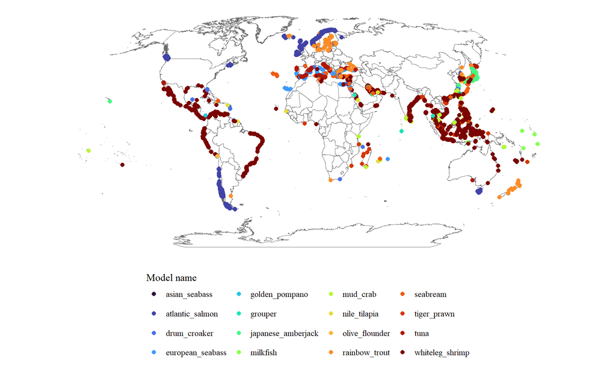

Figure 3: Map of all assigned farms, coloured by model name.

```r
assigned_farms <- file.path(prepdata_path, "assigned_farms.qs") %>%
  qs_read() %>%
  st_transform(crs = crs_robin) %>%
  st_make_valid()

p_bigmap_robinson +
  geom_sf(data = assigned_farms, aes(colour = model_name), size = 2) +
  scale_colour_viridis_d(name = "Model name", option = "turbo") +
  coord_sf() +
  prettyplot() + rm_x_axis() + rm_y_axis() +
  theme(legend.position = "bottom", legend.title = element_text(), legend.title.position = "top")
```

**Plot the extracted farm locations by country**

```r
assigned_farms <- qs_read(file.path(prepdata_path, "assigned_farms.qs"))
lands <- ne_countries(scale = "large", return = "sf")

# Set limits for plots by country?

# iso <- "VNM"
walk(
  unique(assigned_farms$ISO3_Code),
  function(iso) {
    this_assigned <- assigned_farms %>% filter(ISO3_Code == iso)
    this_EEZ <- EEZ_by_FAO_full %>% filter(ISO3_Code == iso)
    this_land <- lands %>% filter(iso_a3 == iso)

    ggplot() +
      geom_sf(data = this_EEZ, aes(colour = F_CODE), fill = NA, linewidth = 0.75) +
      scale_colour_brewer(name   = "FAO Fishing Region", palette = "Set2") +
      new_scale_colour() +
      geom_sf(data = this_land, colour = "black", fill = "lightgrey") +
      geom_sf(data = this_assigned, aes(colour = model_name), size = 1.75) +
      scale_colour_brewer(name   = "Model name", palette = "Dark2") +
      coord_sf() +
      facet_wrap(~model_name) +
      theme_classic() +
      labs(
        title = unique(this_assigned$country),
        x = "Longitude",
        y = "Latitude"
      )

    ggsave(file.path(outs_path, "plots", "farm_locations", paste0(iso, ".png")))
  },
  .progress = T
)
```

**Load saved data for summarising**

```r
all_temps_fnms <- file.path(prepdata_path, "assigned_farms_meanyear") %>%
  list.files(full.names = T)

model_names <- unique(assigned_farms$model_name)

# mn <- model_names[1]
walk(
  model_names,
  function(mn) {
    model_farms <- assigned_farms %>%
      filter(model_name == mn) %>%
      pull(farm_ID)

    model_fnms <- all_temps_fnms %>%
      str_subset(paste0(fix_int(model_farms, 8), collapse = "|"))

    # fnm <- model_fnms[1]
    temps <- map_dfr(
      model_fnms,
      function(fnm) {
        fID <- fnm %>%
          basename() %>%
          str_extract("\\d+(?=\\.qs$)") %>%
          as.integer()
        qd_read(fnm) %>% mutate(farm_ID = fID)
      }
    ) %>%
      mutate(model_name = mn)

    qs_save(
      temps,
      file.path(prepdata_path, "farm_temps_bymodel", paste0("meanyear_farm_temps_", mn, ".qs"))
    )
  },
  .progress = T
)
```

[output not shown]

[output not shown]

[output not shown]

[output not shown]

[output not shown]

[output not shown]

[output not shown]

[output not shown]

[output not shown]

[output not shown]

[output not shown]

## Means of assigned meanyear temperatures

```r
files_bymodel <- file.path(prepdata_path, "farm_temps_bymodel") %>%
  list.files(full.names = T)

# fnm <- files_bymodel[1]
model_name_temps <- map_dfr(
  files_bymodel,
  function(fnm) {
    qs_read(fnm) %>%
      group_by(model_name, doy) %>%
      reframe(sst = mean(sst, na.rm = T))
  }
) %>%
  mutate(model_name = as.factor(model_name))

num_models <- length(levels(model_name_temps$model_name))
```

**Boxplots of all meanyear SST values for each assigned farm, by model name**

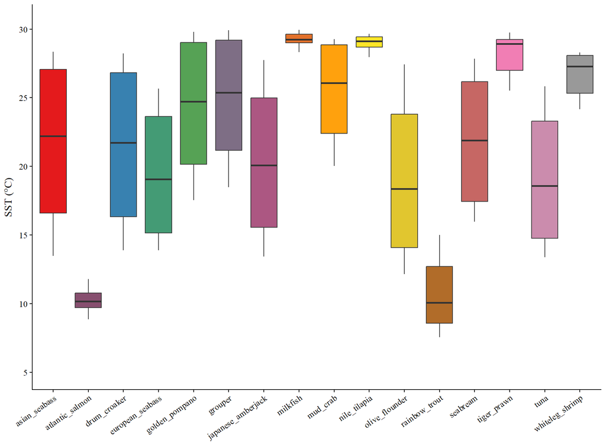

Figure 4: Distribution of SST (°C) experienced by assigned farms across the mean year, grouped by model name.

```r
model_name_temps %>%
  ggplot(aes(x = model_name, y = sst, fill = model_name)) +
  geom_boxplot(outlier.size = 0.8, outlier.alpha = 0.5) +
  scale_fill_manual(
    name   = "Model name",
    values = colorRampPalette(brewer.pal(9, "Set1"))(num_models)
  ) +
  scale_y_continuous(limits = c(5, 30.5), breaks = seq(0, 35, 5)) +
  labs(x = NULL, y = expression("SST ("*degree*"C)")) +
  prettyplot() +
  theme(
    axis.text.x  = element_text(angle = 35, hjust = 1),
    legend.position = "none"
  )
```

**Map of assigned farms coloured by model name**

```
ℹ Adding new coordinate system, which will replace the existing one.
```

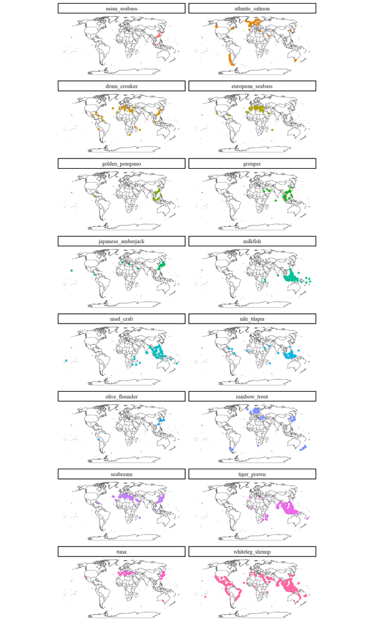

```r
assigned_farms <- qs_read(file.path(prepdata_path, "assigned_farms.qs"))

p_bigmap_robinson +
  geom_sf(
    data  = st_transform(assigned_farms, crs = crs_robin),
    aes(geometry = geometry, colour = model_name),
    size  = 1.5
  ) +
  coord_sf() +
  scale_fill_manual(
    name   = "Model name",
    values = colorRampPalette(brewer.pal(9, "Set1"))(num_models)
  ) +
  facet_wrap(~model_name, ncol = 2) +
  prettyplot() +
  theme() +
  rm_x_axis() + rm_y_axis()
```

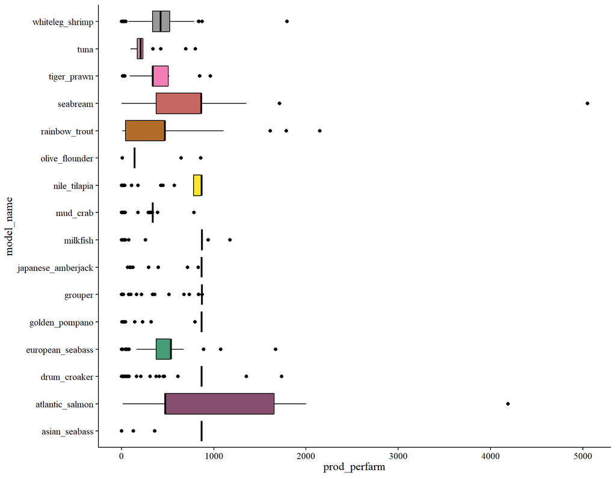

```r
assigned_farms <- qs_read(file.path(prepdata_path, "assigned_farms.qs"))

assigned_farms %>%
  ggplot(aes(x = model_name, y = prod_perfarm, fill = model_name)) +
  geom_boxplot(colour = "black") +
  prettyplot() +
  coord_flip() +
  scale_fill_manual(
    name   = "Model name",
    values = colorRampPalette(brewer.pal(9, "Set1"))(num_models)
  )
```

# References

← Previous: Choosing Species

Next: Parameterise species: `atlantic_salmon` →

## References

Clawson, Gage, Caitlin D. Kuempel, Melanie Frazier, et al. 2022. ‘Mapping the Spatial Distribution of Global Mariculture Production’. *Aquaculture* 553 (May): 738066. https://doi.org/10.1016/j.aquaculture.2022.738066.